# Signal recognition particle receptor beta…

## Figure 4: Best-cluster predicted contact maps over the two true folds.

Predicted contact maps (MSA-Transformer) for the clusters best matching each fold, over the true contacts of fold 1 (upper triangle) and fold 2 (lower). Divergent contacts between clusters are the contact-level signature of fold-switching.

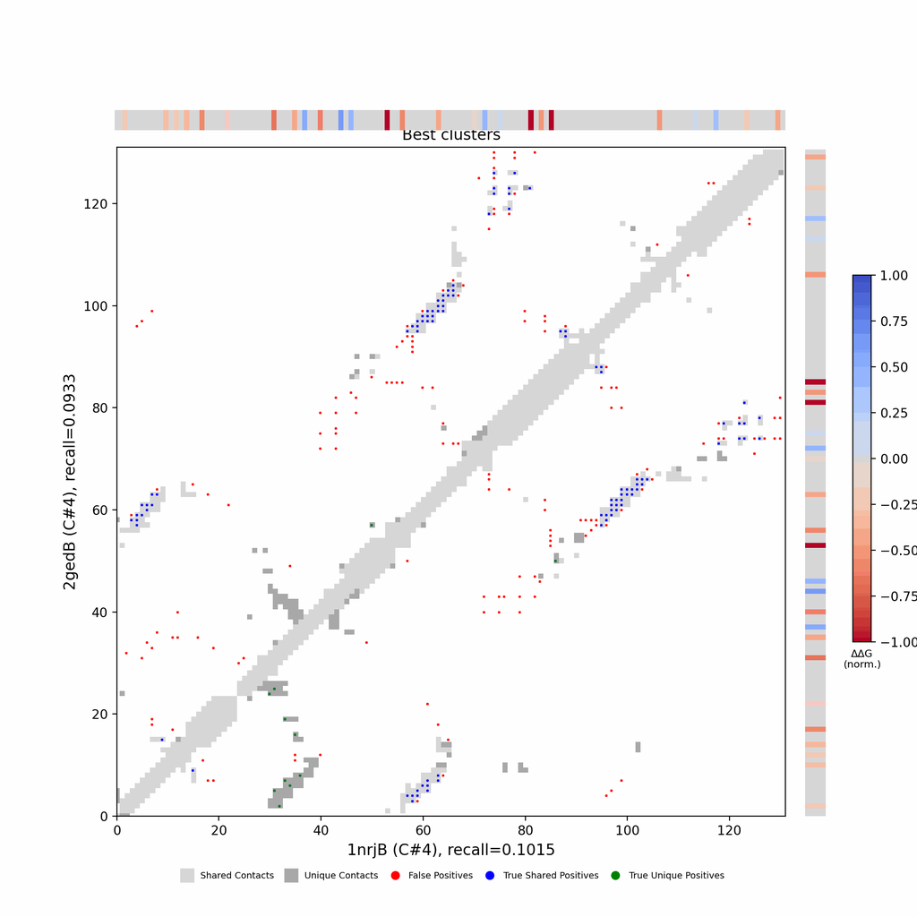

## Figure 5: Per-residue ΔΔG fold-preference contribution

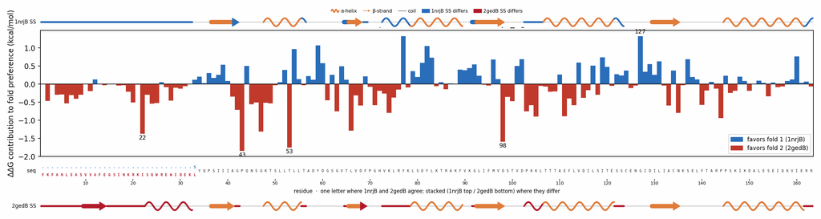

**More figures**

## Figure 6: Deep-MSA contact map panel / Best clusters contact map panel

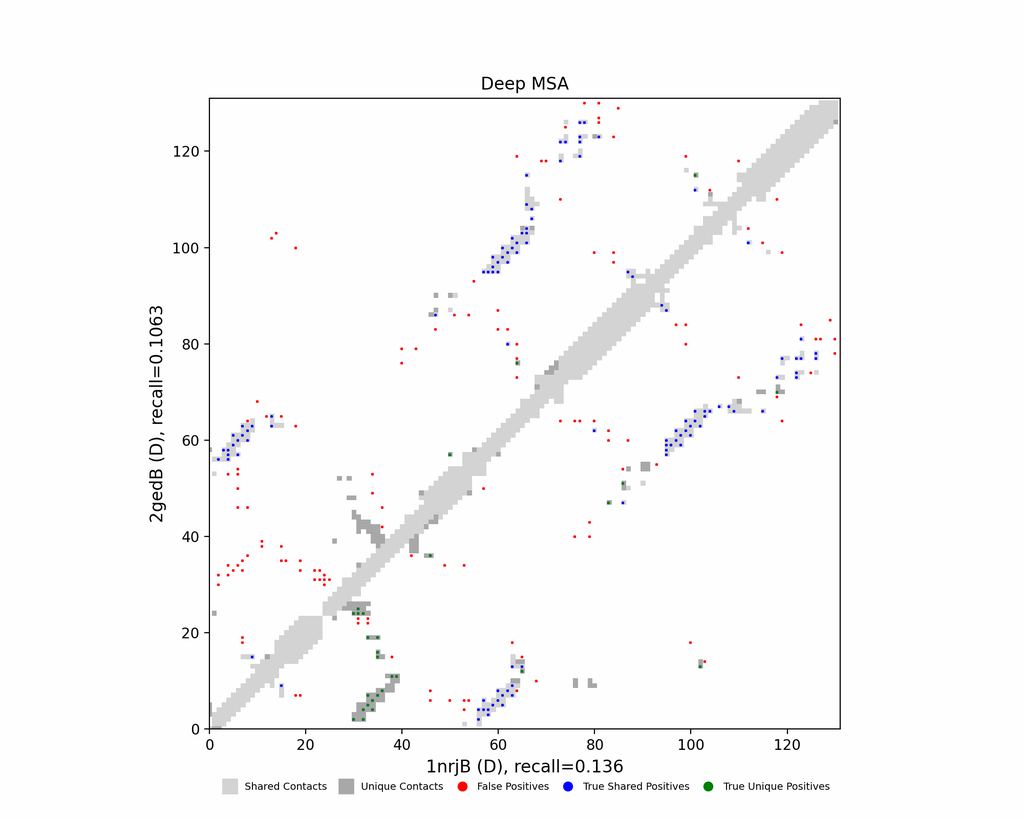

Deep-MSA contact map panel

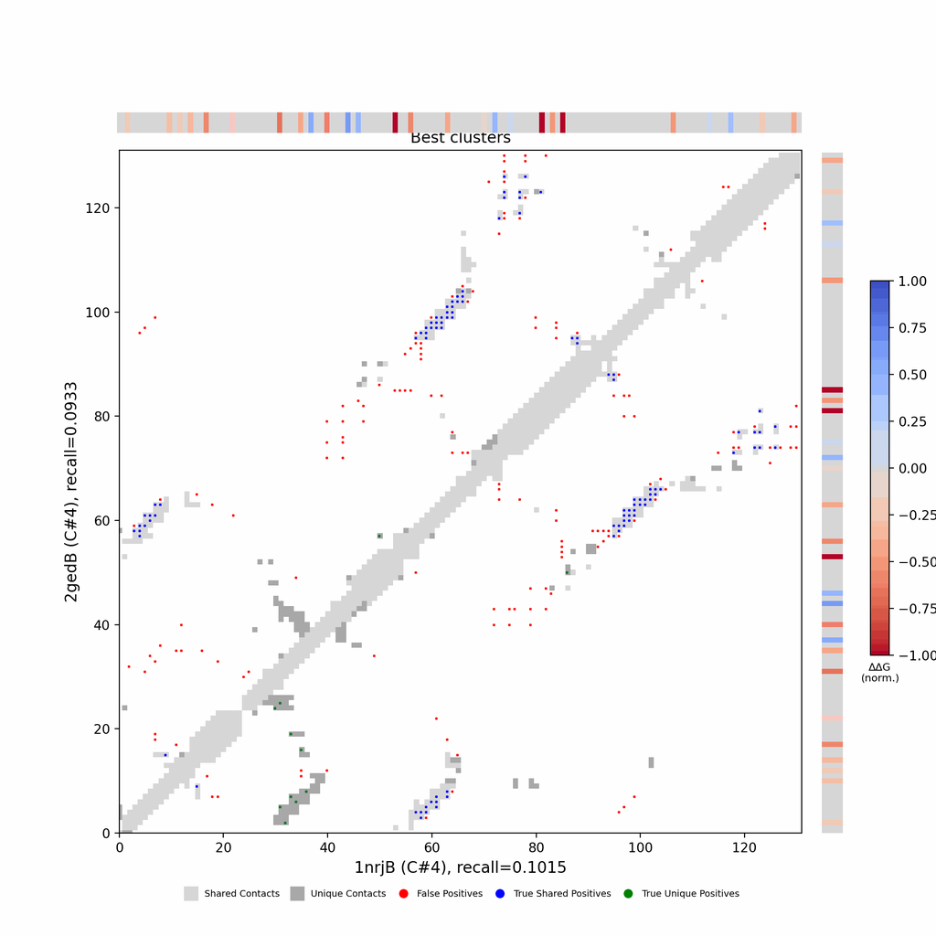

Best clusters contact map panel

## Figure 7: All clusters contact-map mosaic (small multiples).

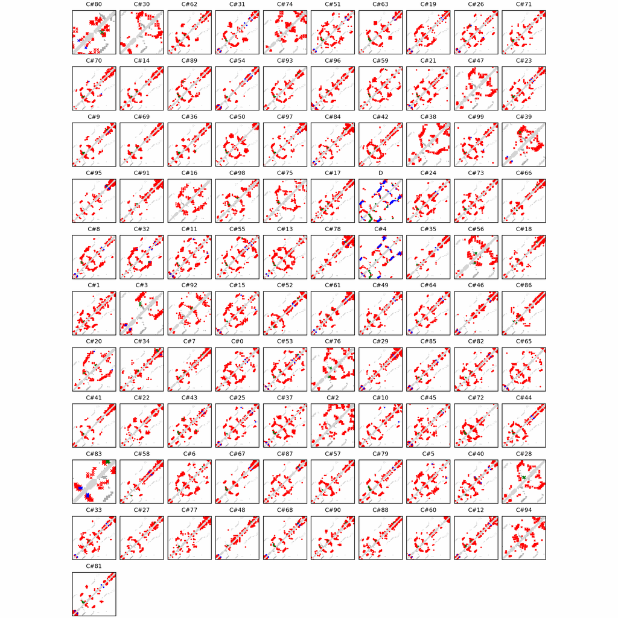

## Figure 8: Phylo null: tree with shuffled cluster fold labels.

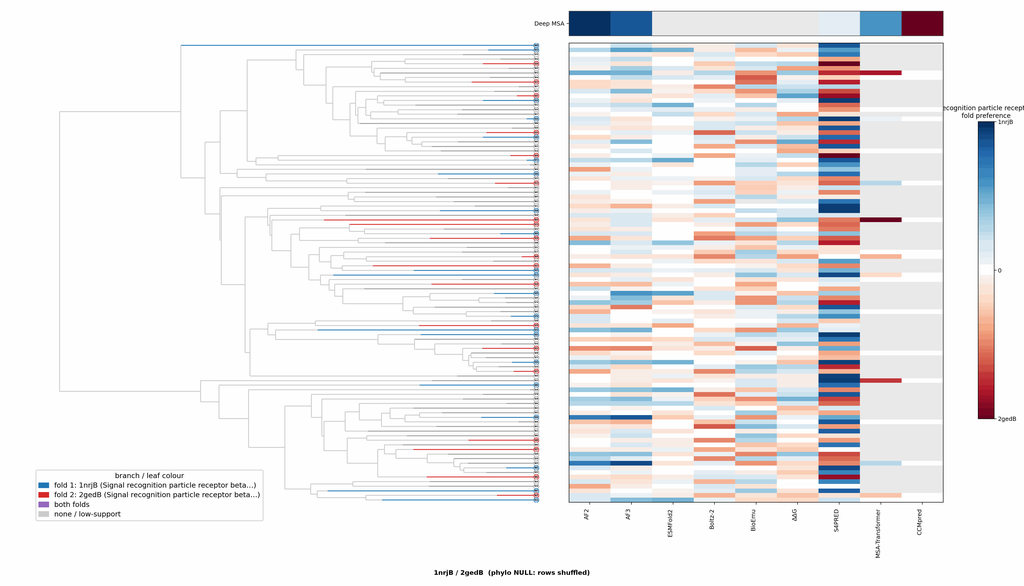

## Cluster metrics table

Per-cluster metrics underlying the figures above.

| cluster | n | neff | AF2_TM1 | AF2_TM2 | AF3_TM1 | AF3_TM2 | RE-MSAT-COM | RE-MSAT1 | RE-MSAT2 | ESM_SEQIDS | ESM_TM1 | ESM_TM2 | ΔΔG_Bias | ΔΔG_Bias_std | ΔΔG_frac_F1 | Boltz2_pref | S4PRED_pref | CCMpred_pref | BioEmu_pref |
| --- | --- | --- | --- | --- | --- | --- | --- | --- | --- | --- | --- | --- | --- | --- | --- | --- | --- | --- | --- |
| Deep | - | - | 0.95 | 0.61 | 0.96 | 0.67 | 0.44 | 0.4 | 0.3 | - | - | - | - | - | - | - | 0.0 | -0.0 | - |
| 000 | 225.0 | 111.0 | 0.26 | 0.35 | 0.39 | 0.36 | 0.0 | 0.01 | 0.01 | 001; 001; 004; 005; 005; 004; 003; 006; 006; 003 | 0.84 ± 0.01 | 0.56 ± 0.01 | -13.98 | 9.59 | 0.0 | 0.02 | 0.01 | 0.0 | -0.05 |
| 001 | 117.0 | 63.0 | 0.42 | 0.39 | 0.42 | 0.36 | 0.0 | 0.01 | 0.01 | 004; 004; 002; 002; 001; 007; 001; 007; 003; 003 | 0.85 ± 0.01 | 0.56 ± 0.01 | -14.57 | 7.34 | 0.0 | 0.1 | 0.0 | 0.0 | 0.03 |
| 002 | 114.0 | 55.0 | 0.28 | 0.3 | 0.42 | 0.32 | 0.0 | 0.0 | 0.0 | 002; 004; 004; 002; 001; 001; 005; 005; 008; 008 | 0.45 ± 0.02 | 0.41 ± 0.03 | -3.93 | 2.84 | 0.1 | 0.08 | -0.01 | 0.0 | -0.03 |
| 003 | 102.0 | 64.0 | 0.77 | 0.58 | 0.8 | 0.61 | 0.03 | 0.01 | 0.01 | 001; 001; 002; 002; 005; 006; 006; 005; 003; 003 | 0.86 ± 0.05 | 0.58 ± 0.02 | -4.71 | 4.07 | 0.2 | 0.03 | -0.01 | 0.0 | 0.13 |
| 004 | 96.0 | 30.0 | 0.55 | 0.52 | 0.53 | 0.41 | 0.24 | 0.11 | 0.13 | 001; 007; 007; 001; 002; 002; 004; 004; 003; 003 | 0.78 ± 0.08 | 0.53 ± 0.04 | -13.06 | 10.22 | 0.1 | 0.09 | -0.0 | 0.0 | 0.01 |
| 005 | 93.0 | 56.0 | 0.88 | 0.62 | 0.95 | 0.61 | 0.0 | 0.01 | 0.01 | 001; 006; 006; 001; 003; 003; 004; 004; 002; 002 | 0.81 ± 0.07 | 0.55 ± 0.04 | -16.63 | 11.03 | 0.1 | -0.04 | -0.01 | 0.0 | 0.12 |
| 006 | 90.0 | 55.0 | 0.36 | 0.43 | 0.33 | 0.41 | 0.0 | 0.0 | 0.0 | 001; 003; 001; 003; 006; 006; 004; 004; 002; 002 | 0.84 ± 0.02 | 0.58 ± 0.01 | -12.93 | 7.86 | 0.0 | 0.06 | 0.01 | 0.0 | -0.03 |
| 007 | 87.0 | 12.0 | 0.48 | 0.41 | 0.49 | 0.44 | 0.0 | 0.0 | 0.0 | 003; 003; 002; 002; 004; 004; 001; 001; 006; 006 | 0.82 ± 0.03 | 0.55 ± 0.04 | -18.36 | 9.27 | 0.0 | 0.03 | -0.0 | 0.0 | 0.0 |
| 008 | 84.0 | 49.0 | 0.3 | 0.35 | 0.34 | 0.32 | 0.0 | 0.0 | 0.01 | 003; 003; 001; 001; 006; 006; 002; 002; 005; 005 | 0.80 ± 0.02 | 0.56 ± 0.00 | -12.4 | 6.12 | 0.0 | 0.1 | -0.01 | 0.0 | -0.02 |
| 009 | 80.0 | 22.0 | 0.41 | 0.41 | 0.52 | 0.53 | 0.0 | 0.0 | 0.0 | 001; 007; 007; 001; 004; 004; 005; 005; 002; 002 | 0.84 ± 0.01 | 0.55 ± 0.01 | -20.79 | 9.91 | 0.0 | -0.0 | 0.0 | 0.0 | -0.01 |
| 010 | 79.0 | 28.0 | 0.37 | 0.36 | 0.42 | 0.35 | 0.0 | 0.0 | 0.01 | 005; 005; 001; 002; 002; 001; 003; 003; 010; 010 | 0.79 ± 0.10 | 0.56 ± 0.01 | -11.51 | 8.55 | 0.1 | 0.09 | -0.01 | 0.0 | 0.0 |
| 011 | 76.0 | 27.0 | 0.51 | 0.42 | 0.73 | 0.55 | 0.03 | 0.02 | 0.02 | 001; 002; 003; 002; 001; 003; 007; 004; 004; 007 | 0.83 ± 0.02 | 0.56 ± 0.01 | -16.7 | 6.01 | 0.0 | 0.2 | 0.0 | 0.0 | 0.04 |
| 012 | 73.0 | 15.0 | 0.32 | 0.33 | 0.46 | 0.44 | 0.0 | 0.0 | 0.0 | 001; 001; 006; 006; 005; 005; 009; 009; 004; 004 | 0.50 ± 0.03 | 0.44 ± 0.05 | -8.17 | 5.77 | 0.1 | 0.1 | 0.02 | 0.0 | -0.0 |
| 013 | 72.0 | 43.0 | 0.44 | 0.42 | 0.53 | 0.52 | 0.0 | 0.0 | 0.01 | 001; 002; 002; 001; 005; 005; 006; 006; 009; 009 | 0.72 ± 0.10 | 0.54 ± 0.05 | -14.31 | 6.44 | 0.0 | 0.01 | -0.01 | 0.0 | -0.03 |
| 014 | 71.0 | 12.0 | 0.42 | 0.4 | 0.52 | 0.44 | 0.0 | 0.0 | 0.01 | 004; 004; 001; 002; 002; 001; 006; 003; 003; 006 | 0.83 ± 0.02 | 0.55 ± 0.01 | -20.24 | 7.02 | 0.0 | 0.09 | -0.0 | 0.0 | -0.0 |
| 015 | 70.0 | 33.0 | 0.37 | 0.35 | 0.36 | 0.36 | 0.0 | 0.01 | 0.0 | 001; 001; 008; 007; 008; 007; 006; 006; 002; 002 | 0.55 ± 0.02 | 0.50 ± 0.03 | -13.61 | 6.42 | 0.1 | 0.04 | 0.02 | 0.0 | -0.0 |
| 016 | 69.0 | 42.0 | 0.43 | 0.36 | 0.46 | 0.46 | 0.0 | 0.0 | 0.0 | 002; 002; 003; 003; 004; 004; 005; 005; 006; 006 | 0.79 ± 0.07 | 0.57 ± 0.04 | -6.24 | 2.37 | 0.0 | 0.08 | 0.02 | 0.0 | -0.03 |
| 017 | 69.0 | 29.0 | 0.44 | 0.42 | 0.47 | 0.38 | 0.0 | 0.0 | 0.0 | 001; 001; 003; 003; 002; 002; 005; 005; 006; 006 | 0.85 ± 0.03 | 0.59 ± 0.01 | -15.91 | 9.83 | 0.1 | -0.02 | -0.0 | 0.0 | -0.01 |
| 018 | 66.0 | 3.0 | 0.64 | 0.49 | 0.64 | 0.47 | 0.0 | 0.0 | 0.0 | - | - | - | -8.65 | 8.35 | 0.2 | 0.27 | -0.01 | - | 0.11 |
| 019 | 66.0 | 20.0 | 0.33 | 0.41 | 0.34 | 0.41 | 0.0 | 0.01 | 0.0 | - | - | - | -12.0 | 8.2 | 0.0 | 0.1 | 0.0 | - | -0.08 |
| 020 | 65.0 | 46.0 | 0.42 | 0.39 | 0.49 | 0.49 | 0.0 | 0.0 | 0.02 | - | - | - | -6.93 | 4.45 | 0.1 | 0.02 | -0.02 | - | -0.01 |
| 021 | 65.0 | 44.0 | 0.43 | 0.47 | 0.38 | 0.46 | 0.0 | 0.0 | 0.01 | - | - | - | -12.01 | 8.57 | 0.1 | 0.11 | 0.02 | - | -0.02 |
| 022 | 65.0 | 13.0 | 0.62 | 0.49 | 0.77 | 0.55 | 0.0 | 0.0 | 0.0 | - | - | - | -11.12 | 6.54 | 0.0 | 0.18 | 0.01 | - | 0.11 |
| 023 | 64.0 | 15.0 | 0.42 | 0.39 | 0.45 | 0.45 | 0.0 | 0.0 | 0.0 | - | - | - | -14.32 | 7.8 | 0.0 | 0.11 | -0.0 | - | 0.01 |
| 024 | 63.0 | 24.0 | 0.33 | 0.45 | 0.41 | 0.43 | 0.0 | 0.0 | 0.0 | - | - | - | -17.22 | 7.55 | 0.0 | 0.0 | -0.01 | - | -0.08 |
| 025 | 63.0 | 24.0 | 0.22 | 0.25 | 0.31 | 0.26 | 0.02 | 0.02 | 0.01 | - | - | - | -16.11 | 6.02 | 0.0 | 0.12 | -0.01 | - | -0.02 |
| 026 | 63.0 | 30.0 | 0.31 | 0.43 | 0.35 | 0.33 | 0.02 | 0.01 | 0.02 | - | - | - | -12.82 | 8.04 | 0.0 | 0.01 | 0.0 | - | -0.08 |
| 027 | 62.0 | 18.0 | 0.43 | 0.48 | 0.38 | 0.38 | 0.0 | 0.0 | 0.01 | - | - | - | -10.61 | 7.28 | 0.0 | 0.09 | -0.01 | - | -0.04 |
| 028 | 62.0 | 38.0 | 0.73 | 0.59 | 0.79 | 0.61 | 0.0 | 0.0 | 0.02 | - | - | - | -2.61 | 3.79 | 0.3 | 0.05 | -0.01 | - | 0.12 |

[output cut: 71 more lines]